# Project: EV Data Analysis

### Name: Ajay

### Batch: Data Science Batch 1st May

### Project Video: https://www.loom.com/share/83a48ed8e8c44ab497f6d45ca0dc8995?sid=86541818-715b-426e-8519-ed9781e71bc1

### GitHub Repository: https://github.com/ajaythakur958/Electric-Vehicle-Data-Analysis-Project

```python
import numpy as np
import pandas as pd
import matplotlib.pyplot as plt
import seaborn as sns
from scipy.stats import ttest_ind
```

# loading data in pandas data frame

```python
df = pd.read_csv("Auta elektryczne.csv")
```

```python
df.head()
```

|  | Car full name | Make | Model | Minimal price (gross) [PLN] | Engine power [KM] | Maximum torque [Nm] | Type of brakes | Drive type | Battery capacity [kWh] | Range (WLTP) [km] | ... | Permissable gross weight [kg] | Maximum load capacity [kg] | Number of seats | Number of doors | Tire size [in] | Maximum speed [kph] | Boot capacity (VDA) [l] | Acceleration 0-100 kph [s] | Maximum DC charging power [kW] | mean - Energy consumption [kWh/100 km] |
| --- | --- | --- | --- | --- | --- | --- | --- | --- | --- | --- | --- | --- | --- | --- | --- | --- | --- | --- | --- | --- | --- |
| 0 | Audi e-tron 55 quattro | Audi | e-tron 55 quattro | 345700 | 360 | 664 | disc (front + rear) | 4WD | 95.0 | 438 | ... | 3130.0 | 640.0 | 5 | 5 | 19 | 200 | 660.0 | 5.7 | 150 | 24.45 |
| 1 | Audi e-tron 50 quattro | Audi | e-tron 50 quattro | 308400 | 313 | 540 | disc (front + rear) | 4WD | 71.0 | 340 | ... | 3040.0 | 670.0 | 5 | 5 | 19 | 190 | 660.0 | 6.8 | 150 | 23.80 |
| 2 | Audi e-tron S quattro | Audi | e-tron S quattro | 414900 | 503 | 973 | disc (front + rear) | 4WD | 95.0 | 364 | ... | 3130.0 | 565.0 | 5 | 5 | 20 | 210 | 660.0 | 4.5 | 150 | 27.55 |
| 3 | Audi e-tron Sportback 50 quattro | Audi | e-tron Sportback 50 quattro | 319700 | 313 | 540 | disc (front + rear) | 4WD | 71.0 | 346 | ... | 3040.0 | 640.0 | 5 | 5 | 19 | 190 | 615.0 | 6.8 | 150 | 23.30 |
| 4 | Audi e-tron Sportback 55 quattro | Audi | e-tron Sportback 55 quattro | 357000 | 360 | 664 | disc (front + rear) | 4WD | 95.0 | 447 | ... | 3130.0 | 670.0 | 5 | 5 | 19 | 200 | 615.0 | 5.7 | 150 | 23.85 |

5 rows × 25 columns

# checking data-types

```python
df.dtypes
```

```
Car full name                              object
Make                                       object
Model                                      object
Minimal price (gross) [PLN]                 int64
Engine power [KM]                           int64
Maximum torque [Nm]                         int64
Type of brakes                             object
Drive type                                 object
Battery capacity [kWh]                    float64
Range (WLTP) [km]                           int64
Wheelbase [cm]                            float64
Length [cm]                               float64
Width [cm]                                float64
Height [cm]                               float64
Minimal empty weight [kg]                   int64
Permissable gross weight [kg]             float64
Maximum load capacity [kg]                float64
Number of seats                             int64
Number of doors                             int64
Tire size [in]                              int64
Maximum speed [kph]                         int64
Boot capacity (VDA) [l]                   float64
Acceleration 0-100 kph [s]                float64
Maximum DC charging power [kW]              int64
mean - Energy consumption [kWh/100 km]    float64
dtype: object
```

# checking duplicates rows

```python
df.duplicated().any()
```

```
np.False_
```

# checking null values

```python
df.info()
```

```
<class 'pandas.core.frame.DataFrame'>
RangeIndex: 53 entries, 0 to 52
Data columns (total 25 columns):
 #   Column                                  Non-Null Count  Dtype
---  ------                                  --------------  -----
 0   Car full name                           53 non-null     object
 1   Make                                    53 non-null     object
 2   Model                                   53 non-null     object
 3   Minimal price (gross) [PLN]             53 non-null     int64
 4   Engine power [KM]                       53 non-null     int64
 5   Maximum torque [Nm]                     53 non-null     int64
 6   Type of brakes                          52 non-null     object
 7   Drive type                              53 non-null     object
 8   Battery capacity [kWh]                  53 non-null     float64
 9   Range (WLTP) [km]                       53 non-null     int64
```

[output cut: 17 more lines]

```python
df.isnull().sum()
```

```
Car full name                             0
Make                                      0
Model                                     0
Minimal price (gross) [PLN]               0
Engine power [KM]                         0
Maximum torque [Nm]                       0
Type of brakes                            1
Drive type                                0
Battery capacity [kWh]                    0
Range (WLTP) [km]                         0
Wheelbase [cm]                            0
Length [cm]                               0
Width [cm]                                0
Height [cm]                               0
Minimal empty weight [kg]                 0
Permissable gross weight [kg]             8
Maximum load capacity [kg]                8
Number of seats                           0
Number of doors                           0
Tire size [in]                            0
Maximum speed [kph]                       0
Boot capacity (VDA) [l]                   1
Acceleration 0-100 kph [s]                3
Maximum DC charging power [kW]            0
mean - Energy consumption [kWh/100 km]    9
dtype: int64
```

# Handling null value

```python
df["Type of brakes"] = df["Type of brakes"].fillna("NA")
df["Boot capacity (VDA) [l]"] = df["Boot capacity (VDA) [l]"].fillna(df["Boot capacity (VDA) [l]"].median())
df["Permissable gross weight [kg]"] = df["Permissable gross weight [kg]"].fillna(
    df["Permissable gross weight [kg]"].median())
df["Maximum load capacity [kg]"] = df["Maximum load capacity [kg]"].fillna(
    df["Maximum load capacity [kg]"].median())
df["Acceleration 0-100 kph [s]"] = df["Acceleration 0-100 kph [s]"].fillna(
    df["Acceleration 0-100 kph [s]"].median())
df["mean - Energy consumption [kWh/100 km]"] = df["mean - Energy consumption [kWh/100 km]"].fillna(
    df["mean - Energy consumption [kWh/100 km]"].median())
```

```python
df.isnull().sum()
```

```
Car full name                             0
Make                                      0
Model                                     0
Minimal price (gross) [PLN]               0
Engine power [KM]                         0
Maximum torque [Nm]                       0
Type of brakes                            0
Drive type                                0
Battery capacity [kWh]                    0
Range (WLTP) [km]                         0
Wheelbase [cm]                            0
Length [cm]                               0
Width [cm]                                0
Height [cm]                               0
Minimal empty weight [kg]                 0
Permissable gross weight [kg]             0
Maximum load capacity [kg]                0
Number of seats                           0
Number of doors                           0
Tire size [in]                            0
Maximum speed [kph]                       0
Boot capacity (VDA) [l]                   0
Acceleration 0-100 kph [s]                0
Maximum DC charging power [kW]            0
mean - Energy consumption [kWh/100 km]    0
dtype: int64
```

```python
df.info()
```

```
<class 'pandas.core.frame.DataFrame'>
RangeIndex: 53 entries, 0 to 52
Data columns (total 25 columns):
 #   Column                                  Non-Null Count  Dtype
---  ------                                  --------------  -----
 0   Car full name                           53 non-null     object
 1   Make                                    53 non-null     object
 2   Model                                   53 non-null     object
 3   Minimal price (gross) [PLN]             53 non-null     int64
 4   Engine power [KM]                       53 non-null     int64
 5   Maximum torque [Nm]                     53 non-null     int64
 6   Type of brakes                          53 non-null     object
 7   Drive type                              53 non-null     object
 8   Battery capacity [kWh]                  53 non-null     float64
 9   Range (WLTP) [km]                       53 non-null     int64
```

[output cut: 17 more lines]

# TASK 1 :- customer has a budget of 350,000 PLN and wants an EV with a minimum range of 400 km.

```python
df_filtered = df[(df["Minimal price (gross) [PLN]"]<=350000) & (df["Range (WLTP) [km]"]>=400)]
df_filtered= df_filtered.sort_values(by=["Range (WLTP) [km]", "Minimal price (gross) [PLN]"], ascending = [False, True])
df_filtered
```

|  | Car full name | Make | Model | Minimal price (gross) [PLN] | Engine power [KM] | Maximum torque [Nm] | Type of brakes | Drive type | Battery capacity [kWh] | Range (WLTP) [km] | ... | Permissable gross weight [kg] | Maximum load capacity [kg] | Number of seats | Number of doors | Tire size [in] | Maximum speed [kph] | Boot capacity (VDA) [l] | Acceleration 0-100 kph [s] | Maximum DC charging power [kW] | mean - Energy consumption [kWh/100 km] |
| --- | --- | --- | --- | --- | --- | --- | --- | --- | --- | --- | --- | --- | --- | --- | --- | --- | --- | --- | --- | --- | --- |
| 40 | Tesla Model 3 Long Range | Tesla | Model 3 Long Range | 235490 | 372 | 510 | disc (front + rear) | 4WD | 75.0 | 580 | ... | 2119.0 | 486.0 | 5 | 5 | 18 | 233 | 425.0 | 4.4 | 150 | 17.05 |
| 41 | Tesla Model 3 Performance | Tesla | Model 3 Performance | 260490 | 480 | 639 | disc (front + rear) | 4WD | 75.0 | 567 | ... | 2119.0 | 486.0 | 5 | 5 | 20 | 261 | 425.0 | 3.3 | 150 | 17.05 |
| 48 | Volkswagen ID.3 Pro S | Volkswagen | ID.3 Pro S | 179990 | 204 | 310 | disc (front) + drum (rear) | 2WD (rear) | 77.0 | 549 | ... | 2280.0 | 412.0 | 5 | 5 | 19 | 160 | 385.0 | 7.9 | 125 | 15.90 |
| 49 | Volkswagen ID.4 1st | Volkswagen | ID.4 1st | 202390 | 204 | 310 | disc (front) + drum (rear) | 2WD (rear) | 77.0 | 500 | ... | 2660.0 | 661.0 | 5 | 5 | 20 | 160 | 543.0 | 8.5 | 125 | 18.00 |
| 8 | BMW iX3 | BMW | iX3 | 282900 | 286 | 400 | disc (front + rear) | 2WD (rear) | 80.0 | 460 | ... | 2725.0 | 540.0 | 5 | 5 | 19 | 180 | 510.0 | 6.8 | 150 | 18.80 |
| 18 | Kia e-Niro 64kWh | Kia | e-Niro 64kWh | 167990 | 204 | 395 | disc (front + rear) | 2WD (front) | 64.0 | 455 | ... | 2230.0 | 493.0 | 5 | 5 | 17 | 167 | 451.0 | 7.8 | 100 | 15.90 |
| 20 | Kia e-Soul 64kWh | Kia | e-Soul 64kWh | 160990 | 204 | 395 | disc (front + rear) | 2WD (front) | 64.0 | 452 | ... | 1682.0 | 498.0 | 5 | 5 | 17 | 167 | 315.0 | 7.9 | 100 | 15.70 |
| 15 | Hyundai Kona electric 64kWh | Hyundai | Kona electric 64kWh | 178400 | 204 | 395 | disc (front + rear) | 2WD (front) | 64.0 | 449 | ... | 2170.0 | 485.0 | 5 | 5 | 17 | 167 | 332.0 | 7.6 | 100 | 15.40 |
| 0 | Audi e-tron 55 quattro | Audi | e-tron 55 quattro | 345700 | 360 | 664 | disc (front + rear) | 4WD | 95.0 | 438 | ... | 3130.0 | 640.0 | 5 | 5 | 19 | 200 | 660.0 | 5.7 | 150 | 24.45 |
| 39 | Tesla Model 3 Standard Range Plus | Tesla | Model 3 Standard Range Plus | 195490 | 285 | 450 | disc (front + rear) | 2WD (rear) | 54.0 | 430 | ... | 2119.0 | 486.0 | 5 | 5 | 18 | 225 | 425.0 | 5.6 | 150 | 17.05 |
| 47 | Volkswagen ID.3 Pro Performance | Volkswagen | ID.3 Pro Performance | 155890 | 204 | 310 | disc (front) + drum (rear) | 2WD (rear) | 58.0 | 425 | ... | 2270.0 | 540.0 | 5 | 5 | 18 | 160 | 385.0 | 7.3 | 100 | 15.40 |
| 22 | Mercedes-Benz EQC | Mercedes-Benz | EQC | 334700 | 408 | 760 | disc (front + rear) | 4WD | 80.0 | 414 | ... | 2940.0 | 445.0 | 5 | 5 | 19 | 180 | 500.0 | 5.1 | 110 | 21.85 |

12 rows × 25 columns

## b.) Group by the manufacturer

```python
grouped = df_filtered.groupby(["Make", "Model", "Car full name"])
grouped
```

```
<pandas.core.groupby.generic.DataFrameGroupBy object at 0x000001C4EB255E80>
```

## c.) Average battery capacity for each manufacturer.

```python
maker_avg = df_filtered.groupby(["Make"])["Battery capacity [kWh]"].mean().round(2).sort_values(ascending=False)
print(maker_avg)
```

```
Make
Audi             95.00
BMW              80.00
Mercedes-Benz    80.00
Volkswagen       70.67
Tesla            68.00
Hyundai          64.00
Kia              64.00
Name: Battery capacity [kWh], dtype: float64
```

### Audi provides the highest battery capacity, followed by BMW and Mercedes-Benz, while Kia provides the least.

### Higher battery capacity leads to a higher range.

# TASK 2 :- Finding the outliers in the mean - Energy consumption [kWh/100 km] column

```python
df.head(1)
```

|  | Car full name | Make | Model | Minimal price (gross) [PLN] | Engine power [KM] | Maximum torque [Nm] | Type of brakes | Drive type | Battery capacity [kWh] | Range (WLTP) [km] | ... | Permissable gross weight [kg] | Maximum load capacity [kg] | Number of seats | Number of doors | Tire size [in] | Maximum speed [kph] | Boot capacity (VDA) [l] | Acceleration 0-100 kph [s] | Maximum DC charging power [kW] | mean - Energy consumption [kWh/100 km] |
| --- | --- | --- | --- | --- | --- | --- | --- | --- | --- | --- | --- | --- | --- | --- | --- | --- | --- | --- | --- | --- | --- |
| 0 | Audi e-tron 55 quattro | Audi | e-tron 55 quattro | 345700 | 360 | 664 | disc (front + rear) | 4WD | 95.0 | 438 | ... | 3130.0 | 640.0 | 5 | 5 | 19 | 200 | 660.0 | 5.7 | 150 | 24.45 |

1 rows × 25 columns

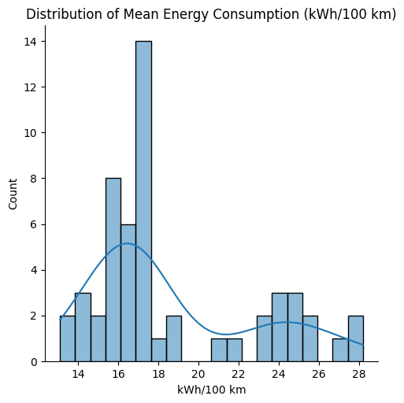

```python
## checking distribution of data column
col_energy = df["mean - Energy consumption [kWh/100 km]"]

sns.displot(col_energy, kde = True, bins=20)
plt.title("Distribution of Mean Energy Consumption (kWh/100 km)")
plt.xlabel("kWh/100 km")
plt.ylabel("Count")
plt.show()
```

### The distribution of energy consumption is not perfectly normal, it is slightly right-skewed.

### A smaller group of vehicles shows higher consumption values around 24–28 kWh/100 km, creating a second minor peak

# BoxPlot to detect Outliers

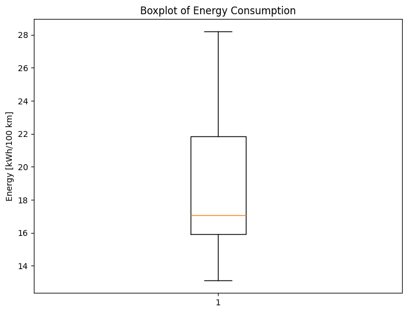

```python
plt.figure(figsize=(8, 6))
plt.boxplot(col_energy)
plt.title("Boxplot of Energy Consumption")
plt.ylabel("Energy [kWh/100 km]")
plt.show()
```

## No outliers are visible under the standard IQR rule, confirming a consistent dataset.

## The slightly higher values (27–28) are on the upper whisker but still within the non-outlier range.

# Detecting Outliers with IQR Range

```python
# detecting outlier with IQR

Q1 = col_energy.quantile(0.25) #first quartile
Q3 = col_energy.quantile(0.75) #third quartile

IQR = (Q3 - Q1) #Interquartile Range (middle 50% of data)

lower_bound = Q1 - 1.0 * IQR #lower bound
upper_bound = Q3 + 1.0 * IQR #upper bound

outliers = df[ (col_energy < lower_bound) | (col_energy > upper_bound) ]
```

```python
outliers[["Car full name","Make","Model","mean - Energy consumption [kWh/100 km]"]]
```

|  | Car full name | Make | Model | mean - Energy consumption [kWh/100 km] |
| --- | --- | --- | --- | --- |
| 51 | Mercedes-Benz EQV (long) | Mercedes-Benz | EQV (long) | 28.2 |

## With the standard 1.5×IQR rule, the boxplot showed no outliers.

## To check for extreme cases, we applied 1.0×IQR rule.

## Under this rule, we identified one high outlier with mean energy consumption of 28.2 kWh/100 km.

# TASK 3 :- if there's a strong relationship between battery capacity and range.

## a.) Visualization

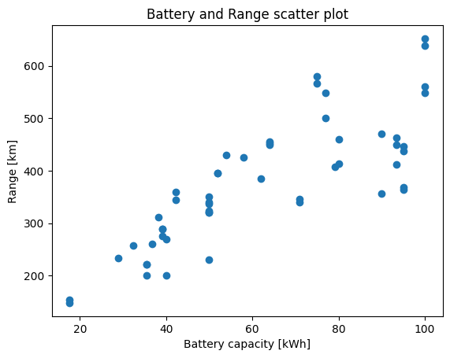

```python
x = df["Battery capacity [kWh]"]
y = df["Range (WLTP) [km]"]

plt.scatter(x,y)
plt.xlabel("Battery capacity [kWh]")
plt.ylabel("Range [km]")
plt.title("Battery and Range scatter plot")
plt.show()
```

## Positive Relationship

- As **battery capacity (kWh)** increases, the **range (km)** also increases.
- This suggests a direct correlation: higher capacity batteries generally provide higher driving range.

## Outliers

- A few points deviate from the trend. some cars with large battery capacity but having lower range.
- These could be affect of **less efficiency, higher weight, or design differences**.

## Conclusion

- There is a **strong positive correlation** between battery capacity and range.
- However, range is **not determined solely** by battery size.
- Factors like **vehicle efficiency, aerodynamics, and energy consumption** also matters and may explain the outliers.

# TASK 4 :- Build an EV recommendation Class

```python
df.head(1)
```

|  | Car full name | Make | Model | Minimal price (gross) [PLN] | Engine power [KM] | Maximum torque [Nm] | Type of brakes | Drive type | Battery capacity [kWh] | Range (WLTP) [km] | ... | Permissable gross weight [kg] | Maximum load capacity [kg] | Number of seats | Number of doors | Tire size [in] | Maximum speed [kph] | Boot capacity (VDA) [l] | Acceleration 0-100 kph [s] | Maximum DC charging power [kW] | mean - Energy consumption [kWh/100 km] |
| --- | --- | --- | --- | --- | --- | --- | --- | --- | --- | --- | --- | --- | --- | --- | --- | --- | --- | --- | --- | --- | --- |
| 0 | Audi e-tron 55 quattro | Audi | e-tron 55 quattro | 345700 | 360 | 664 | disc (front + rear) | 4WD | 95.0 | 438 | ... | 3130.0 | 640.0 | 5 | 5 | 19 | 200 | 660.0 | 5.7 | 150 | 24.45 |

1 rows × 25 columns

```python
class EvRecommender:
    def __init__(self, ev_df):
        self.ev_df = ev_df

    def recommend(self, budget, min_range, min_battery):
        filtered_data = self.ev_df[
            (self.ev_df["Minimal price (gross) [PLN]"] <= budget) &
            (self.ev_df["Range (WLTP) [km]"] >= min_range) &
            (self.ev_df["Battery capacity [kWh]"] >= min_battery)
            ]
        filtered_data = filtered_data.sort_values( by = ["Minimal price (gross) [PLN]", "Range (WLTP) [km]"], ascending = [True, False] )
        result = filtered_data.head(3)
        return result[["Car full name","Make","Model","Minimal price (gross) [PLN]","Battery capacity [kWh]","Range (WLTP) [km]"]]

recommender = EvRecommender(df)
budget = int(input("Enter your budget:"))
min_range = int(input("Enter minimum Range required [km]"))
min_battery = int(input("Enter minimum battery Required [kWh]"))

recommender.recommend(budget, min_range, min_battery)
```

|  | Car full name | Make | Model | Minimal price (gross) [PLN] | Battery capacity [kWh] | Range (WLTP) [km] |
| --- | --- | --- | --- | --- | --- | --- |
| 48 | Volkswagen ID.3 Pro S | Volkswagen | ID.3 Pro S | 179990 | 77.0 | 549 |
| 49 | Volkswagen ID.4 1st | Volkswagen | ID.4 1st | 202390 | 77.0 | 500 |
| 40 | Tesla Model 3 Long Range | Tesla | Model 3 Long Range | 235490 | 75.0 | 580 |

# TASK 5 :- Hypothesis Testing: If there is a significant difference in the average Engine power between Tesla and Audi.

```python
# Extract Tesla and Audi data
tesla_power = df[df['Make'] == 'Tesla']['Engine power [KM]']
audi_power = df[df['Make'] == 'Audi']['Engine power [KM]']
```

## Null Hypothesis: There is no significant difference between the average engine power of Tesla and Audi.

## Alternate Hypothesis: There is a significant difference between the average engine power of Tesla and Audi.

### Checking the mean values and sample data to perform the t-test analysis.

```python
print("Mean for audi manufacturer is:",audi_power.mean())
print(audi_power)
print("_"*80)
print("Mean for tesla manufacturer is:",tesla_power.mean())
print(tesla_power)
```

```
Mean for audi manufacturer is: 392.0
0    360
1    313
2    503
3    313
4    360
5    503
Name: Engine power [KM], dtype: int64
________________________________________________________________________________
Mean for tesla manufacturer is: 533.0
39    285
40    372
41    480
42    525
43    772
44    525
45    772
Name: Engine power [KM], dtype: int64
```

```python
# Perform independent t-test (Welch’s test)
t_val, p_val = ttest_ind(tesla_power, audi_power, equal_var=False)

print("T-value:", t_val)
print("P-value:", p_val)
```

```
T-value: 1.7939951827297178
P-value: 0.10684105068839565
```

#### t-value is 1.7939951827297178

#### p-value is 0.10684105068839565

#### Since we got p-value (0.1068) > 0.05 (alpha), we fail to reject the null hypothesis.

#### This means there is no significant difference in the average engine power of Tesla and Audi based on the given data.

## Recommendation

#### We may get more precise and reliable results if we have a larger dataset.

#### For decision-making, buyers should also look at other factors like range, battery life, charging options, and overall performance instead of only engine power.

#### From a business point of view, showing a mix of power, efficiency, and features gives more value to customers than just focusing on engine power.

## Conclusion

#### Even tho Tesla shows a higher average engine power compared to Audi but difference is not statistically significant because (p-value = 0.106 > 0.05).

#### This means the observed difference may be due to random variation rather than an actual performance gap.

#### Therefore, we cannot conclude that one brand consistently has higher engine power than the other based only on this dataset.